# P1: Test a Perceptual Phenomenon

Andre Marais

Sunday, August 2, 2015

**Question 1: Identify variables in the experiment**  
1. Independent variable would be the two test, or the actual words that were used in the both the congruent and incongruent tests.  
2. The dependent variable would be the measured reading time

**Question 2: Establish a hypothesis and statistical test**  
We want to test if there’s a difference in the completion times between the Congruent and Incongruent tests. Since the test measures the reading time in seconds for both tests, we’ll use the average of the differences between the Congruent and Incongruent completion times to test our hypothesis. It seems reasonable to test if it takes *longer* to complete the Incongruent test. So the null hypothesis would be that the Incongruent completion times come from a population where the mean is at the very most equal to the Congruent population’s mean. The alternative hypothesis would then state that the Incongruent completion times come from a population with a mean larger than that of the Congruent population’s.

Stated formally:  
**H<sub>0</sub>:** μ<sub>C</sub> ≥ μ<sub>I</sub>  
**H<sub>1</sub>:** μ<sub>C</sub> < μ<sub>I</sub>  
Where μ<sub>C</sub> represents the average reading time for the Congruent population, and μ<sub>I</sub> represents the average reading time for the Incongruent population.  
Since we don’t know what the population parameters are for the Congruent and Incongruent tests, we’ll use the t-test. We can use the paired samples t-test, since we have the reading times of each subject on both the Congruent and Incongruent tests. And since we’re testing for directional difference, we’ll use the one-tailed t-test

**Question 3: Report descriptive statistics**  
Average of reading times:

```
##   Congruent Incongruent  Difference
##   14.051125   22.015917    7.964792
```

Standard deviation of reading times:

```
##   Congruent Incongruent  Difference
##    3.559358    4.797057    4.864827
```

```
##   Congruent Incongruent  Difference
##   19.339492   22.483686    8.020707
```

**Question 4: Plot the data**

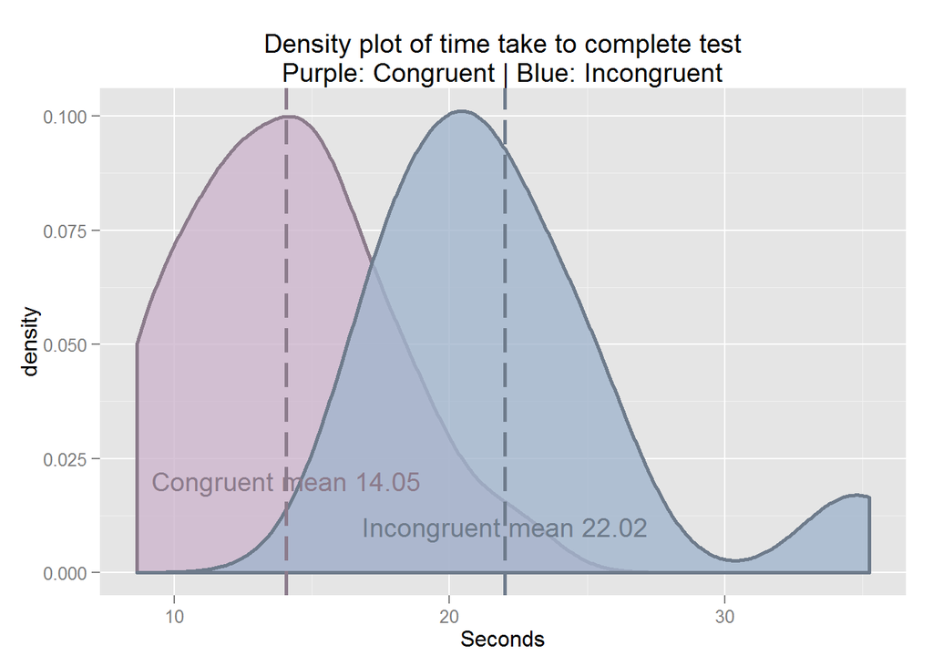

From the graph you can see there’s an increase in reading time for the Incongruent test. Barring the outliers, it seems like the reading times might come from a normal distribution.

**Question 5: Perform the statistical test and interpret your results**  
As stated previously, we’ll be using a one-tailed t-test to see if the Incongruent values come from a population with a larger mean value than that of the Congruent test. We can use the conventional α value of $0.05$. Since the sample size $24$, the Degrees of Freedom is $23$. Using this information, we can derive that the critical value of the t-statistic $1.713872$.

Since we’re only testing for a difference, and not *how much of* a difference, we’ll be using this formula to calculate the t-statistic for the mean differences: $t = \frac{\overline{x}_{D} - 0}{s/\sqrt{n}}$, where $\overline{x}_{D}$ signifies the average of the differences and $s$ the standard deviation of the differences.  
Calculating the t-statistic: $t = \frac{7.964792 - 0}{4.864827/\sqrt{24}} = 8.0207$  
Since $8.0207$ is larger than $1.713872$, we can reject the null hypothesis in favor of the alternative.

**Question 6: Digging deeper and extending the investigation**  
I imagine there are two different parts of your brain which deciphers what you see - one for colour and the other for the word itself. When both the word and the color are the same, there’s no issue. But when they differ, your brain might need to do a double-check before you can decide what the correct answer is. Using arrows with embedded words might also be a test which can measure this effect. For instance the first screen have arrows with the appropriate direction imbedded onto them (ie an up arrow has the word ‘up’ written on it). The second screen would naturally have the words and directions mixed up.